# BIO392-CNV.Frequency

asievi

2023-09-27

# Tumor information

Breast Carcinom: Breast Carcinoma is the most common Cancer in Women. It can also occur in men but it’s far more likely in woman. Cancer airises when breast cells start to grow abnormally. Aberration leading to activation of oncogens and loss of tumor-suppressors are thought to be early breast cancer driver. Cells divide more rapildy than healthy cells and do accumulate and form an oddly shaped tissue. Because it needs constantly more space, when its limited is exceeded it begins to spread (metastasize). Hormonal, lifestyle and environmental factors may increase your risk of breast cancer. The likelihood of breast cancer have been identified with an increase in specific chromosmal gen mutation.

The NCIt codes is C9245

## Access the CNV frequency Data

### load library

```r
library(pgxRpi)
```

### Access Data

```r
freq <- pgxLoader( type='frequency',output = 'pgxfreq', filters = "NCIT:C9245")
```

### Metadata information is

```r
freq$meta
```

```
##         code                     label sample_count
## 1 NCIT:C9245 Invasive Breast Carcinoma         3796
## 2      total                                   3796
```

### The data looks like this

```r
freq$data$'NCIT:C9245'[c(1:3),]
```

```
##      filters reference_name   start     end gain_frequency loss_frequency no
## 1 NCIT:C9245              1       0  400000          2.397          1.159  1
## 2 NCIT:C9245              1  400000 1400000          4.083          7.877  2
## 3 NCIT:C9245              1 1400000 2400000          2.608          6.981  3
```

# Visualisation

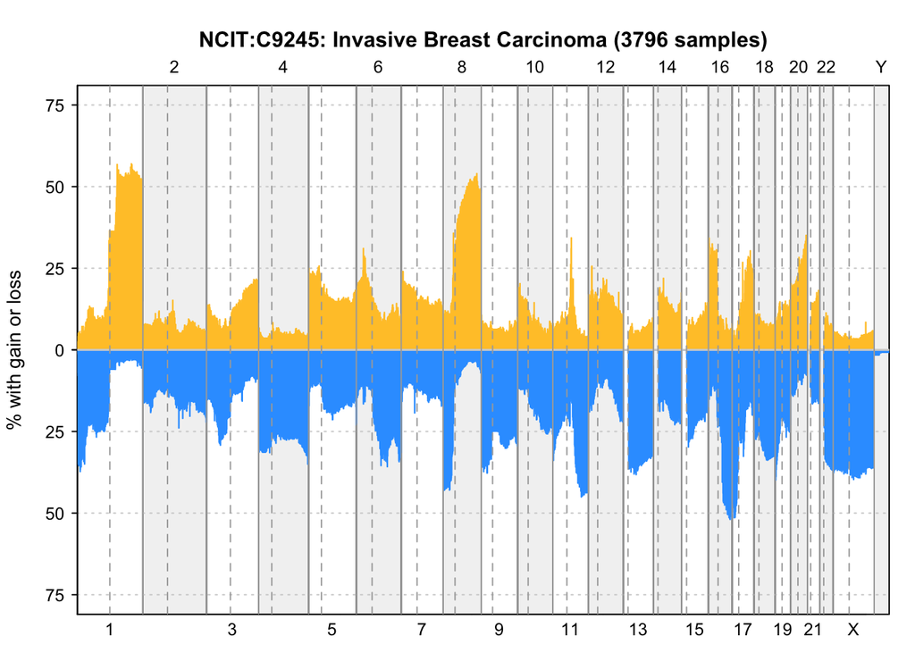

```r
pgxFreqplot(freq)
```

On the Upperside of the Graph the duplication of specific Chromosoms are shown in orange.  
On the lowerside in blue the is illustrated the loss of DNA on the referred chromosom.

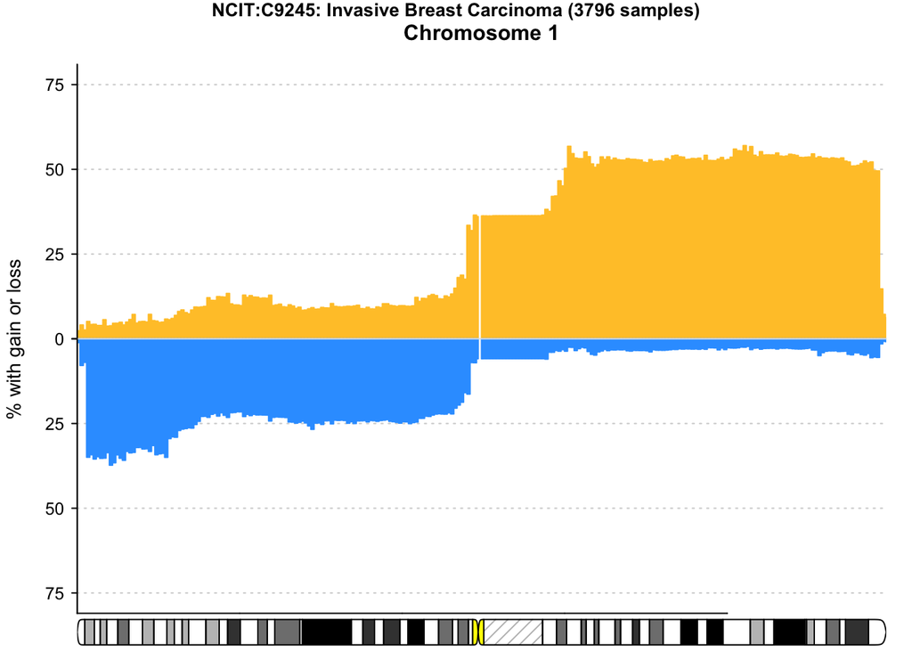

```r
pgxFreqplot(freq, chrom=1)
```

The most duplications occur in the Chromosom 1. It seems to have severe influence in the development of breast cancer.

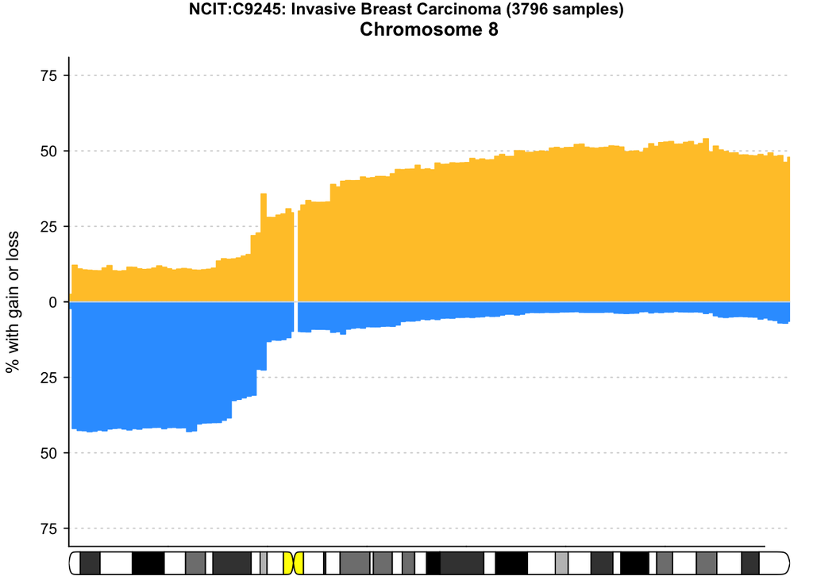

```r
pgxFreqplot(freq, chrom=8)
```

The chromosome 8 shows to have a great influence in loss of function (blue) as well as in duplication (orange)

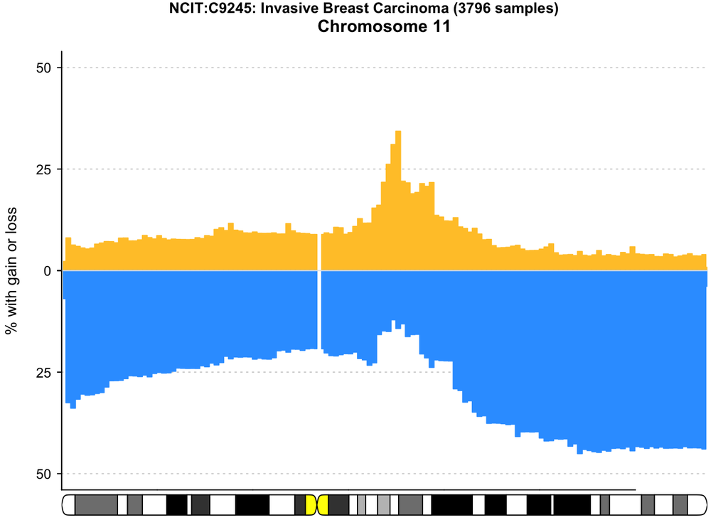

```r
pgxFreqplot(freq, chrom=11)
```

This more detailed graph of chromosom 11 demonstrate the big amount of loss in blue.

# Analysis

Study:  
1q, 8q, 17q, 20q amplification  
8p, 11q, 16q, 17p loss

As a result in both data sets the chromosom 1, 8, 11, 20 are detrimental in relation to breast carcinoma.